# Answering Business Questions using SQL

Osvaldo Illescas

In this project, we’re going to use SQL to answer some business questions.We’ll work with a modified version of a database called [Chinook](https://github.com/lerocha/chinook-database#:~:text=Chinook%20is%20a%20sample%20database,single%20and%20multiple%20database%20servers.). The Chinook database contains information about various elements in a fictional digital music shop, such as artists, songs, and albums, as well as the shop’s employees, customers, and the customers’ purchases. All this information is contained in 11 tables. You can find a schema of the tables below:

[figure not shown]

**Chinook schema**

In this project, instead of using the *dbConnect()* and the *dbDisconnect()* functions, we will create a **helper function**. Let’s start by importing libraries, assigning the database and writing this functions:

```r
library(RSQLite)
library(DBI)

db <- 'chinook.db'

run_query <- function(query) {

  conn <- dbConnect(SQLite(), db)
  q <- dbGetQuery(conn, query)
  dbDisconnect(conn)

  return(q)
}

show_tables <- function() {
  query = "SELECT name,
                  type
             FROM sqlite_master
            WHERE type IN ('table', 'view')"
  return(run_query(query))
}

show_tables()
```

```
##              name  type
## 1           album table
## 2          artist table
## 3        customer table
## 4        employee table
## 5           genre table
## 6         invoice table
## 7    invoice_line table
## 8      media_type table
## 9        playlist table
## 10 playlist_track table
## 11          track table
```

We can see that our function returns all tables in the database, as shown in the schema. Imagine next situation: The Chinook record store has just signed a deal with a new record label, and you’re in charge of choosing the first three albums to be added to the store. There are four albums to choose from, and all four are by artists who don’t have any tracks in the store right now. The record label specializes in artists from the USA, and they have given Chinook some money to advertise the new albums in the USA. To aid in selecting albums, we’re interested in finding out which genres sell the best in the USA.

We’ll need to write a query to find out which genres sell the most tracks in the USA, and then create a visualization of that data using SQL.

```r
usa_tracks = '
WITH tracks_usa AS (
    SELECT
        il.*
      FROM invoice_line il
     INNER JOIN invoice i ON i.invoice_id = il.invoice_id
     INNER JOIN customer c ON c.customer_id = i.customer_id
     WHERE c.country = "USA")

SELECT
    g.name genre,
    COUNT(tu.invoice_line_id) tracks_sold,
    CAST(COUNT(tu.invoice_line_id) AS Float) / (
        SELECT COUNT(*)
          FROM tracks_usa) percentage
  FROM tracks_usa tu
 INNER JOIN track t ON t.track_id = tu.track_id
 INNER JOIN genre g ON g.genre_id = t.genre_id
 GROUP BY 1
 ORDER BY 2 DESC
 LIMIT 10;
 '

run_query(usa_tracks)
```

```
##                 genre tracks_sold percentage
## 1                Rock         561 0.53377735
## 2  Alternative & Punk         130 0.12369172
## 3               Metal         124 0.11798287
## 4            R&B/Soul          53 0.05042816
## 5               Blues          36 0.03425309
## 6         Alternative          35 0.03330162
## 7                 Pop          22 0.02093245
## 8               Latin          22 0.02093245
## 9         Hip Hop/Rap          20 0.01902950
## 10               Jazz          14 0.01332065
```

We can now use ggplot to visualize our result:

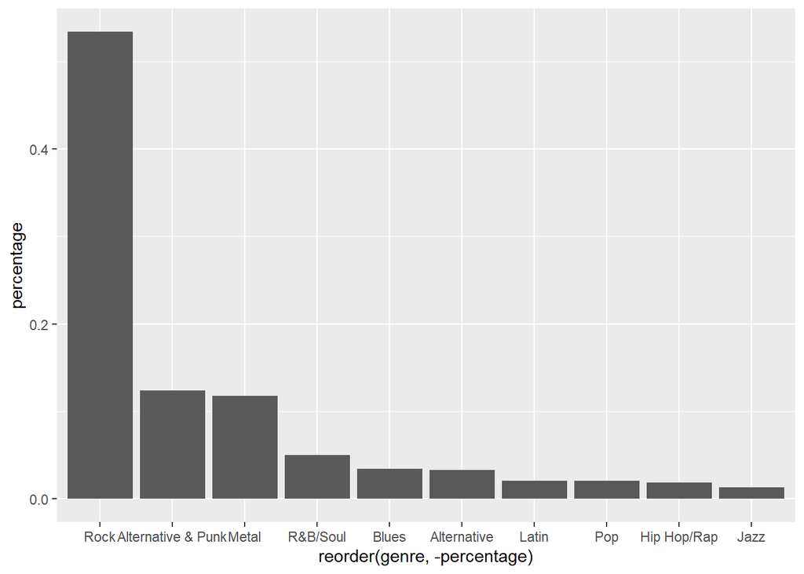

```r
library(ggplot2)
genre_sales = run_query(usa_tracks)
ggplot(data = genre_sales, aes(x = reorder(genre, -percentage),
                               y = percentage)) +
  geom_bar(stat = "identity")
```

- Rock: “Dark Side of the Moon”
- Punk: “Red Tone”
- Blues: “Slim Jim Bites”

Each customer for the Chinook store gets assigned to a sales support agent within the company when they first make a purchase. You have been asked to analyze the purchases of customers belonging to each employee to see if any sales support agent is performing either better or worse than the others.

```r
employee_analyze = '

WITH total_dollars AS (
  SELECT
      i.customer_id,
      c.support_rep_id,
      SUM(i.total) total
    FROM invoice i
    INNER JOIN customer c ON i.customer_id = c.customer_id
    GROUP BY 1, 2
)

SELECT
    e.first_name || " " || e.last_name name,
    td.total
  FROM total_dollars td
 INNER JOIN employee e ON e.employee_id = td.support_rep_id
 GROUP BY 1;
 '

run_query(employee_analyze)
```

```
##            name  total
## 1  Jane Peacock 108.90
## 2 Margaret Park  72.27
## 3 Steve Johnson  82.17
```

We can visualize this result:

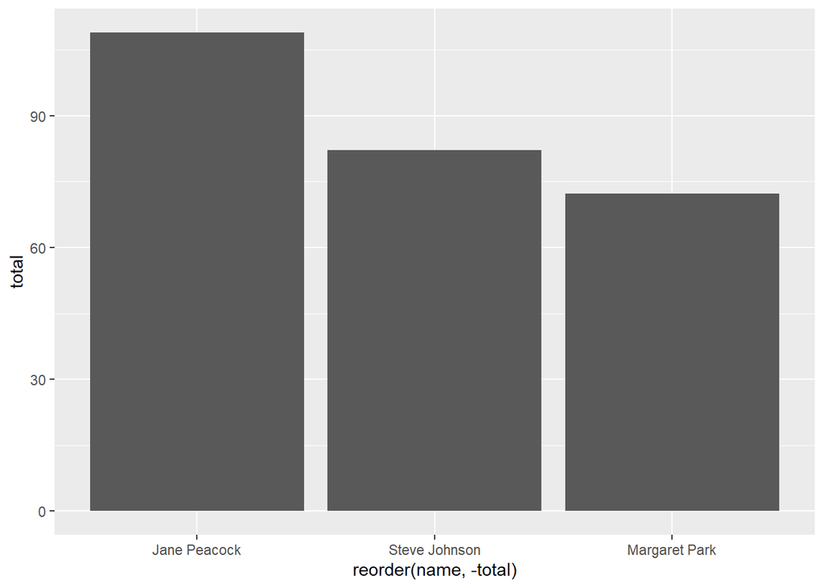

```r
employee_sales = run_query(employee_analyze)
ggplot(data = employee_sales, aes(x = reorder(name, -total),
                               y = total)) +
  geom_bar(stat = "identity")
```

Next task is to analyze the sales data for customers from each different country. You have been given guidance to use the country value from the customers table, and ignore the country from the billing address in the invoice table.

In particular, we have been directed to calculate data, for each country, on the:

- Total number of customers
- Total value of sales
- Average value of sales per customer
- Average order value

Because there are a number of countries with only one customer, we should group these customers as “Other” in the analysis.

```r
sales_by_country = '
WITH country_or_other AS
    (
     SELECT
       CASE
           WHEN (
                 SELECT count(*)
                 FROM customer
                 where country = c.country
                ) = 1 THEN "Other"
           ELSE c.country
       END AS country,
       c.customer_id,
       il.*
     FROM invoice_line il
     INNER JOIN invoice i ON i.invoice_id = il.invoice_id
     INNER JOIN customer c ON c.customer_id = i.customer_id
    )
SELECT
    country,
    customers,
    total_sales,
    average_order,
    customer_lifetime_value
FROM
    (
    SELECT
        country,
        count(distinct customer_id) customers,
        SUM(unit_price) total_sales,
        SUM(unit_price) / count(distinct customer_id) customer_lifetime_value,
        SUM(unit_price) / count(distinct invoice_id) average_order,
        CASE
            WHEN country = "Other" THEN 1
            ELSE 0
        END AS sort
    FROM country_or_other
    GROUP BY country
    ORDER BY sort ASC, total_sales DESC
    );
'
run_query(sales_by_country)
```

```
##           country customers total_sales average_order customer_lifetime_value
## 1             USA        13     1040.49      7.942672                80.03769
## 2          Canada         8      535.59      7.047237                66.94875
## 3          Brazil         5      427.68      7.011148                85.53600
## 4          France         5      389.07      7.781400                77.81400
## 5         Germany         4      334.62      8.161463                83.65500
## 6  Czech Republic         2      273.24      9.108000               136.62000
## 7  United Kingdom         3      245.52      8.768571                81.84000
## 8        Portugal         2      185.13      6.383793                92.56500
## 9           India         2      183.15      8.721429                91.57500
## 10          Other        15     1094.94      7.448571                72.99600
```

We can now see this results in a plot:

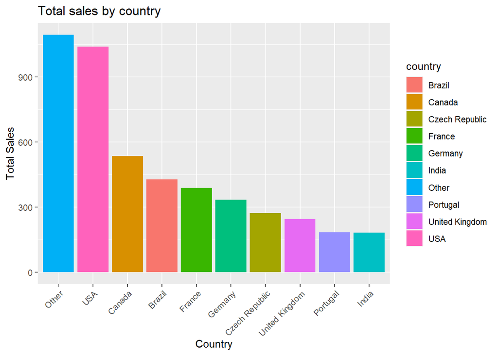

```r
country_metrics = run_query(sales_by_country)
ggplot(data = country_metrics, aes(x = reorder(country, -total_sales),
                                   y = total_sales,
                                   fill = country)) +
  geom_bar(stat = "identity") +
  labs(
    title = "Total sales by country",
    x = "Country",
    y = "Total Sales"
  ) + theme(axis.text.x = element_text(angle = 45, hjust = 1))
```

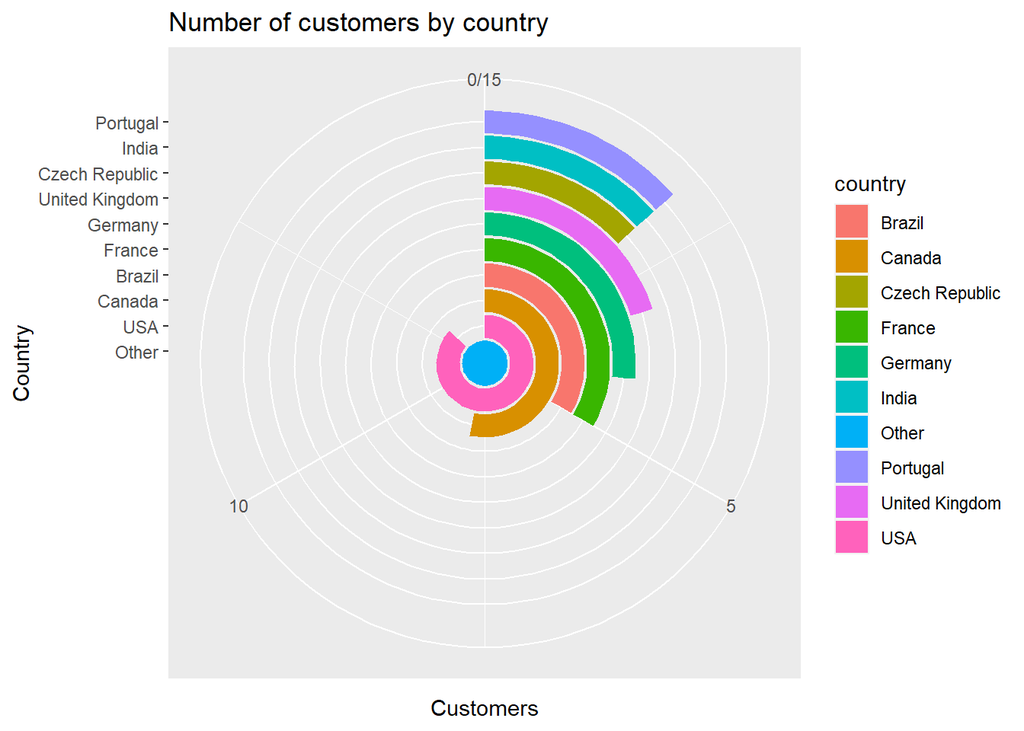

```r
ggplot(data = country_metrics, aes(x = reorder(country, -customers),
                                   y = customers,
                                   fill = country)) +
  geom_bar(stat = "identity") +
  coord_polar("y") +
  labs(
    title = "Number of customers by country",
    x = "Country",
    y = "Customers"
  )
```

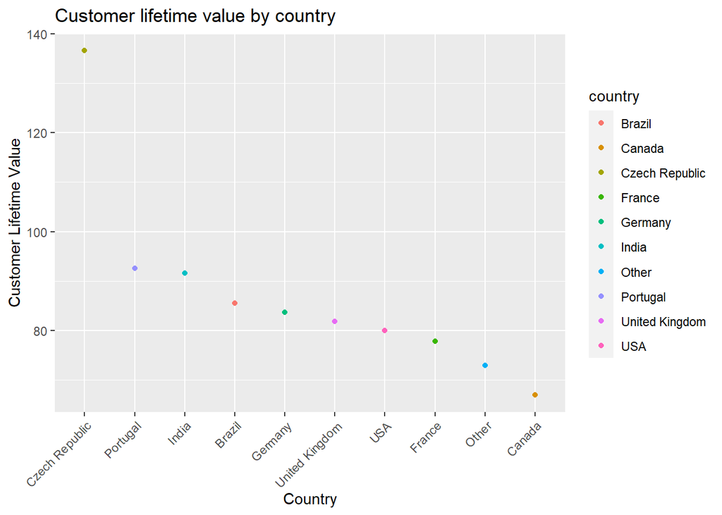

```r
ggplot(data = country_metrics, aes(x = reorder(country, -customer_lifetime_value),
                                   y = customer_lifetime_value,
                                   color = country)) +
  geom_point(stat = "identity") +
  labs(
    title = "Customer lifetime value by country",
    x = "Country",
    y = "Customer Lifetime Value"
  ) + theme(axis.text.x = element_text(angle = 45, hjust = 1))
```